# R trialdata_report

Cixiao Jiang, Mengjin Yan, Yu Pan, Xin Ye

10/06/2021

```r
knitr::opts_chunk$set(echo = TRUE)
```

# 《Feasibility study on the operation and development of Mini-sternotomy–data from the patient survey on time to postoperative discharge after aortic valve replacement》

## Abstract

Purpose：{#sec:Intro} Aortic valve replacement (AVR) is a common surgical procedure to treat heart diseases such as aortic stenosis. Full sternotomy (FS) is considered the `gold standard’ surgical procedure for AVR, while Mini-sternotomy (MS) is an alter- native procedure that is attractive due to potentially shorter patient recovery times.  
FS surgery is the standard mode of AVR surgery, while MS is a new treatment. Although it is better than the former in postoperative recovery, we have some questions about the safety and therapeutic effect of MS surgery. In this study, we hope to compare the surgical indications and postoperative effects of 490 patients with FS and 429 patients with MS, so as to objectively evaluate the efficacy and safety of MS. At the same time, we hope to further study whether the main factor affecting the postoperative quality of life of patients undergoing AVR surgery is the improvement of surgical methods. In other words, we hope to prove that the research and promotion of MS surgery has practical significance in clinical practice.

Result：  
There was no significant difference between the two groups in preoperative indexes and nurses’ working experience (P > 0.05); 14 cases died in FS operation group and 13 cases died in MS operation group. The mortality of the two groups was similar. In terms of postoperative situation and postoperative quality of life, it can be considered that the difference is statistically significant (P < 0.05). LM model shows that the main influencing factors affecting patients’ postoperative quality of life are surgical methods and hospital expenses.

## 1 Introduction

Aortic valve replacement (AVR) is a kind of thoracic and cardiovascular surgery in which artificial valves are used to replace the original diseased or abnormal heart valves. The indications are aortic stenosis and aortic regurgitation. Aortic valve replacement (AVR) can be performed in two ways: median sternotomy (FS) or small upper sternotomy (MS):  
MS approach. With the patient anesthetized in accordance with standard protocol, skin was incised from halfway between the suprasternal notch and the sternal angle to the level of the fourth intercostal space, approximately 8 cm. The manubrium was divided in the midline from the suprasternal notch inferiorly and then into the right fourth intercostal space. The thymus was divided, and the pericardium was opened, exposing the ascending aorta, aortic root, and right atrial appendage. A 300 U/kg loading dose of unfractionated heparin followed by boluses of 5000 U was administered to achieve activated clotting time >450 seconds. The aorta was cannulated using a wired flexible aortic cannula. The right atrial appendage was cannulated using a flat venous cannula, and CPB was initiated. The ascending aorta was cross-clamped and intermittent, antegrade, cold blood cardioplegia administered. The aorta was then incised open in an oblique or transverse fashion, the diseased valve was excised, and the annulus was decalcified. A suitably sized aortic valve prosthesis was inserted using either horizontal mattress 2-0 Ethicon sutures or semi-continuous 2-0 Proline sutures. Surgeons adopted either of these suture techniques and adhered to the same technique irrespective of the type of valve prosthesis or the surgical approach. The autotomy was then closed, the heart was deaired, right atrial and ventricular epicardial pacing wires were inserted, and the patient was weaned off. Once satisfactory functioning of the aortic valve prosthesis was confirmed by TOE, heparin was reversed with protamine (1 mg/100 U of heparin). Chest drains were inserted into the anterior mediastinum, posterior pericardial space, and pleural space as necessary. Sternal wires were inserted, and the incision was closed in layers. Conversion to FS was performed to ensure patient safety if access proved difficult or if intraoperative complications occurred.  
FS approach. Anesthesia and positioning of patients was the same as for the MS approach. The skin incision was made between the suprasternal notch and the xiphoid process and sternum divided in the midline from the suprasternal notch to the xiphoid process. A 2-stage venous cannula was used for atrial cannulation. The remaining steps were similar to those for the MS approach.  
From the operation methods of the two operations, we can see that the wound of MS operation is relatively small and the degree of pain is light, which has obvious advantages over the traditional FS operation, but its safety and effectiveness are not clear. We need to further verify our guess through research. It is hoped that through the study of two AVR surgical methods, we can get favorable results for patients’ clinical treatment.

## 2 Data and Statistical Methodology

### 2.1 Research object

The Rdata file contains the simulated results of a clinical trial comparing patients who underwent MS to patients who underwent FS. It includes 24 variables.

| Variable name | Variable meaning |
| --- | --- |
| PatientId | a unique numerical identier for each patient |
| Allocated | the surgery (MS or FS) which the patient was scheduled to undergo |
| Received | the actual surgery (MS or FS) that the patient underwent |
| Born | the patient’s date of birth |
| Surgery | the patient’s date of surgery |
| Consented | the date on which the patient consented to participate in the study |
| EuroSCORE | a measure of the patient’s risk of death (as a percentage),calculated prior to surgery |
| Male | a binary variable taking the value TRUE if the patient is ma, or FALSE otherwise |
| MIstrokeTIA | a binary variable indicating whether the patient had suffered a myocardial infarction, stroke or a transient ischaemic attack in the 30 days prior to surgery |
| CCS | a measure of the severity of the patient’s chest pain on a scale of 0 to 4 (Canadian Cardiovascular Society classication of angina). |
| BMI | body mass index (kg=m2), a measure of the patient’s obesity. |
| COPD | a binary variable indicating whether the patient had chronic ob- structive pulmonary disease prior to surgery. |
| WalkingUnassisted | a binary variable indicating whether the patient was able to walk without assistance prior to surgery. |
| CareHome | a binary variable indicating whether the patient lives in a care home. |
| FEV1baseline | pre-surgery lung function, FEV1 (forced expiratory volume in one second), measured by spirometry (litres). |
| Discharge | the date of the patient’s discharge from hospital (i.e. the end of the patient’s post-operative hospital stay). |
| DeathDate | the date of death for any patients who died within a year of surgery. |
| CauseOfDeath | the cause of death for any patients who died within a year of surgery. |
| Nurse | a unique identier for the nurse who measured the patient’s pain. |
| NurseExperience | the number of years of experience of the nurse who measured the patient’s pain score. |
| Pain | the patient’s post-operative pain score, on a scale of 0 to 100, on the day after surgery. |
| FEV1 | post-surgery lung function, FEV1 (forced expiratory volume in one second), measured by spirometry (litres) on the day of the patient’s hospital discharge. |
| Cost | relevant costs ($) over the first year following surgery (including the costs of surgeries, drugs and hospital visits). |
| QALYs | quality adjusted life years, a measure of the patient’s quality of life in the year after surgery, on a scale of 0 to 1. |

### 2.2 Data Load

```r
###Load the data and packages used
setwd("~/Desktop/Clinical trial data")
data <- get(load("~/Desktop/Clinical trial data/TrialData.Rdata"))
library(dplyr)
library(lubridate)
library(lattice)
library(MASS)
library(nnet)
library(mice)
library(ggplot2)
library(corrgram)
library(vcd)
library(stats)
library(zoo)
library(lmtest)
library(gvlma)
library(Rmisc)
library(plyr)
library(ggridges)
library(glmnet)
library(foreign)
```

### 2.3 Data Processing

#### 2.3.1 Variable Conversion

From the existing data, we can see that it contains five columns of dates, namely, date of birth, time of investigation, time of operation, time of discharge and time of death.  
(1) Since the follow-up time is only one year after the operation, the vast majority of patients are in a state of survival during the follow-up time. Moreover, among the dead patients, the causes of death are diverse, so it is difficult to analyze whether it is related to the operation. Therefore, we do not consider the time of death for the time being, and delete the two columns of time of death and cause of death.  
(2) Then, we can calculate the age of the patient at the time of operation from the time of birth and the time of operation. From the time of operation and the time of discharge, we can calculate the recovery time of the patient after operation, and establish two new variables, age (unit: year) and recovery time (unit: day).

```r
#The age at the time of surgery was obtained from the difference between the date of birth and the date of surgery
data = mutate(data, age=year(as.period(interval(data$Born, data$Surgery),'year')))#Assign the growth of age to ‘data’
age <- year(as.period(interval(data$Born, data$Surgery),'year'))
#The postoperative recovery time was calculated from the discharge time and operation date
data = mutate(data, recovery_time=day(as.period(interval(data$Surgery, data$Discharge),'day')))#An assignment is used in the data to increase a column of postoperative recovery time
recovery_time <- day(as.period(interval(trialdata$Surgery, trialdata$Discharge),'day'))
data <- data[ , !names(data) %in% c("DeathDate","CauseOfDeath")] #Select all variables except these two variables to generate a new data frame
data <- data[ , !names(data) %in% c("Born","Surgery","Consented","Discharge")]
#After generating two new variables, delete four original variables to make the data more concise
```

#### 2.3.2 Variable Missing Value in R

We first check the overall lack of data step by step.

```r
#Count the number of all missing values
sum(is.na(data))
```

```
## [1] 54
```

```r
#Confirm the proportion of all missing values
mean(is.na(data))
```

```
## [1] 0.002854123
```

```r
#Count the number of incomplete samples in behavioral units
sum(!complete.cases(data))
```

```
## [1] 27
```

```r
#Proportion of incomplete samples
mean(!complete.cases(data))
```

```
## [1] 0.02854123
```

It can be seen that there are not many missing values. Next, we use a more intuitive way to display the missing values in a list.

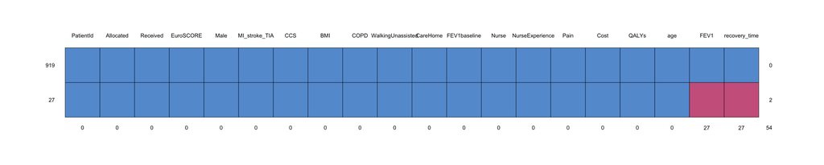

```
##     PatientId Allocated Received EuroSCORE Male
## 919         1         1        1         1    1
## 27          1         1        1         1    1
##             0         0        0         0    0
##     MI_stroke_TIA CCS BMI COPD WalkingUnassisted
## 919             1   1   1    1                 1
## 27              1   1   1    1                 1
##                 0   0   0    0                 0
##     CareHome FEV1baseline Nurse NurseExperience
## 919        1            1     1               1
## 27         1            1     1               1
##            0            0     0               0
##     Pain Cost QALYs age FEV1 recovery_time
## 919    1    1     1   1    1             1  0
## 27     1    1     1   1    0             0  2
##        0    0     0   0   27            27 54
```

```r
md.pattern(data)
```

From the missing list, it can be found that 27 patients did not leave the hospital and died for various reasons. Therefore, their pulmonary function test and discharge date are missing, but we can’t simply delete them. This part of the data can also judge the advantages and disadvantages of the operation. Therefore, we make the missing sequence into a separate data frame for observation.

```r
list <-which(rowSums(is.na(data)) > 0)
#Rows wicth missing values in the dataset.
data_NA <- data[list,]
#Extract rows with missing values.
data <- data[-list,]
#Produces a row with no missing values.
sum(is.na(data))
```

```
## [1] 0
```

```r
#Check the number of all missing values again.
```

#### 2.3.3 Variable Filtering

We analyzed the existing variables, some of which belong to preoperative patient indications, such as age, BMI, CCS, degree of chest pain, etc., and some belong to postoperative indicators, such as pain score, postoperative vital capacity, patient quality of life, etc. Our purpose is to analyze whether there are significant differences in preoperative patient characteristics and postoperative actual effects between the two surgical methods. Through the data research of relevant operations, we decided not to consider the variables: nurse and allocated. Delete these two variables to obtain a new data frame data.

```r
data <- data[ , !names(data) %in% c("Nurse","Allocated")]
```

#### 2.3.4 Create subset

Then, we decided to create a variety of data subsets to facilitate subsequent research from different perspectives.  
In order to study the influencing factors that determine the operation mode, only the preoperative patient characteristic variables are selected to generate the data set ‘data_ before’； At the same time, for the possible follow-up research, we selected the postoperative characteristics and surgical methods to generate the data set ‘data_ after’。

```r
data_before <- data[c("Received","EuroSCORE","Male","MI_stroke_TIA","CCS","BMI","COPD","WalkingUnassisted","CareHome","FEV1baseline","age")]
data_after <- data[c("Received","NurseExperience","Pain","FEV1","Cost","QALYs","recovery_time")]
```

Then we divide the data into ‘data_ FS’ and ‘data_ MS’。

```r
#According to the actual operation mode, FS and MS were divided into two new data sets
data_FS <- data[which(data$Received == "FS"), ]
data_MS <- data[which(data$Received == "MS"), ]
```

### 2.4 Research Method

Using R-4.0.5 software, the two groups of data were analyzed according to the way of operation, and the variables were tested by Wilcoxon rank-sum test. If P-value is less than 0.05, it can be considered that the difference is statistically significant. The stepwise regression method was used to help establish the LM regression model, find out the main influencing factors affecting the quality of life of postoperative patients, and verify the advantages and necessity of MS surgery. If P-value is less than 0.05, it can be considered that the model result is significant.

## 3 Practical Data Analysis

### 3.1 Descriptive Statistics

#### 3.1.1 Preoperative Quantitative Variables

For preoperative data set ’data_ Before ’quantitative variables were used to make density maps to observe the overall preoperative indications of the patients.

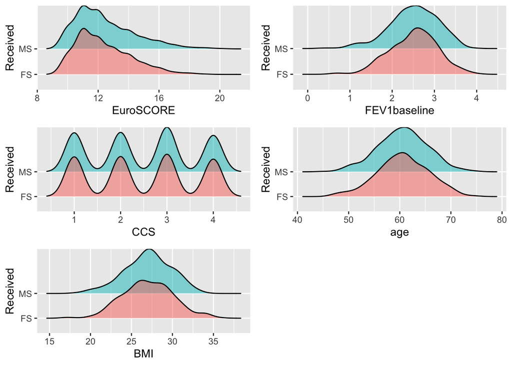

```r
data_d1 <- data[c("Received","EuroSCORE","CCS","BMI","FEV1baseline","age")]
p1 <- ggplot(data = data_d1, mapping = aes(
   x = EuroSCORE,
   y = Received,
   fill = Received))+ geom_density_ridges(alpha = 0.5) + guides(fill = FALSE) +labs(x = "EuroSCORE",y = "Received")

p2 <- ggplot(data = data_d1, mapping = aes(
   x = CCS,
   y = Received,
   fill = Received))+ geom_density_ridges(alpha = 0.5) + guides(fill = FALSE) +labs(x = "CCS",y = "Received")

p3 <- ggplot(data = data_d1, mapping = aes(
   x = BMI,
   y = Received,
   fill = Received))+ geom_density_ridges(alpha = 0.5) + guides(fill = FALSE) +labs(x = "BMI",y = "Received")

p4 <- ggplot(data = data_d1, mapping = aes(
   x = FEV1baseline,
   y = Received,
   fill = Received))+ geom_density_ridges(alpha = 0.5) + guides(fill = FALSE) +labs(x = "FEV1baseline",y = "Received")

p5 <- ggplot(data = data_d1, mapping = aes(
   x = age,
   y = Received,
   fill = Received))+ geom_density_ridges(alpha = 0.5) + guides(fill = FALSE) + labs(x = "age",y = "Received")

multiplot(p1,p2,p3,p4,p5,cols = 2)
```

The qualitative variables of preoperative data set’data_before’ were visualized by mosaic plot, and the overall preoperative fingers of patients under the two surgical methods were observed.  
Male,MI_stroke_TIA,COPD,WalkingUnassisted,CareHome。  
In a mosaic plot, the area of a nested rectangle is proportional to the cell frequency, which is the frequency in the multidimensional contingency table. Colors and / or shadows can represent the residual values of the fitted model.

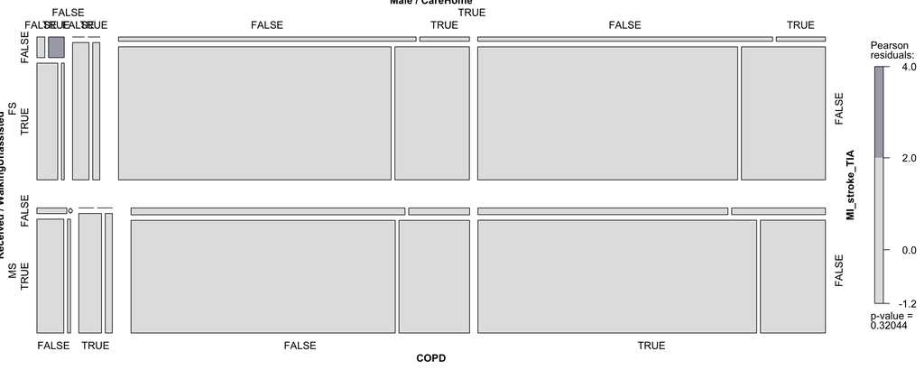

```r
data_e1 <- data[c("Received","Male","MI_stroke_TIA","COPD","WalkingUnassisted","CareHome")]
mosaic(~Received+Male+MI_stroke_TIA+COPD+WalkingUnassisted+CareHome,data=data_e1,shade=TRUE,legend=TRUE)
```

#### 3.1.2 Preoperative Qualitative Variables

The distribution of classification variables in different operations of FS and MS was observed separately, and the stacked bar graph was used for visualization.

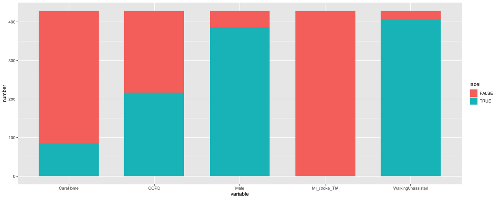

```r
data_e1_MS <- data_e1[which(data$Received == "MS"), ]
data_e1_FS <- data_e1[which(data$Received == "FS"), ]

data_e2_MS <- data.frame(variable=c("Male","MI_stroke_TIA","COPD","WalkingUnassisted","CareHome","Male","MI_stroke_TIA","COPD","WalkingUnassisted","CareHome"),
                        number=c(length(which(data_e1_MS[,2]=="TRUE")),length(which(data_e1_MS[,3]=="TRUE")),length(which(data_e1_MS[,4]=="TRUE")),length(which(data_e1_MS[,5]=="TRUE")),length(which(data_e1_MS[,6]=="TRUE")),length(which(data_e1_MS[,2]=="FALSE")),length(which(data_e1_MS[,3]=="FALSE")),length(which(data_e1_MS[,4]=="FALSE")),length(which(data_e1_MS[,5]=="FALSE")),length(which(data_e1_MS[,6]=="FALSE"))),
                        label=c("TRUE","TRUE","TRUE","TRUE","TRUE","FALSE","FALSE","FALSE","FALSE","FALSE"))

data_e2_FS <- data.frame(variable=c("Male","MI_stroke_TIA","COPD","WalkingUnassisted","CareHome","Male","MI_stroke_TIA","COPD","WalkingUnassisted","CareHome"),
                        number=c(length(which(data_e1_FS[,2]=="TRUE")),length(which(data_e1_FS[,3]=="TRUE")),length(which(data_e1_FS[,4]=="TRUE")),length(which(data_e1_FS[,5]=="TRUE")),length(which(data_e1_FS[,6]=="TRUE")),length(which(data_e1_FS[,2]=="FALSE")),length(which(data_e1_FS[,3]=="FALSE")),length(which(data_e1_FS[,4]=="FALSE")),length(which(data_e1_FS[,5]=="FALSE")),length(which(data_e1_FS[,6]=="FALSE"))),
                        label=c("TRUE","TRUE","TRUE","TRUE","TRUE","FALSE","FALSE","FALSE","FALSE","FALSE"))

ggplot(data_e2_MS,aes(variable,number,fill=label))+
  geom_bar(stat="identity",position="stack",width = 0.7)
```

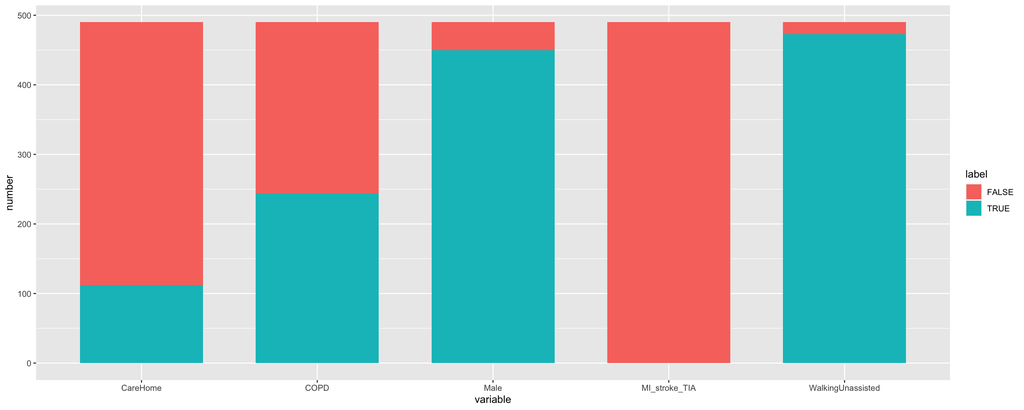

```r
ggplot(data_e2_FS,aes(variable,number,fill=label))+
  geom_bar(stat="identity",position="stack",width = 0.7)
```

#### 3.1.3 Postoperative Quantitative Variables

Data of postoperative data set_ After visualization was performed to observe the overall situation of patients after operation. The characteristic variables of patients after operation were quantitative variables, so we did multi group density map visualization again.

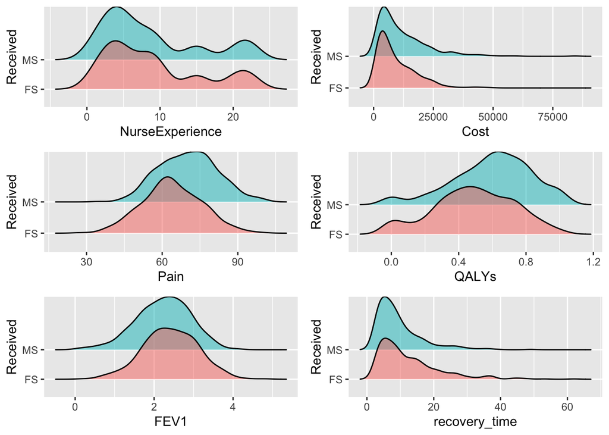

```r
data_after <- data[c("Received","NurseExperience","Pain","FEV1","Cost","QALYs","recovery_time")]
q1 <- ggplot(data = data_after, mapping = aes(
   x = NurseExperience,
   y = Received,
   fill = Received))+ geom_density_ridges(alpha = 0.5) + guides(fill = FALSE) +labs(x = "NurseExperience",y = "Received")

q2 <- ggplot(data = data_after, mapping = aes(
   x = Pain,
   y = Received,
   fill = Received))+ geom_density_ridges(alpha = 0.5) + guides(fill = FALSE) +labs(x = "Pain",y = "Received")

q3 <- ggplot(data = data_after, mapping = aes(
   x = FEV1,
   y = Received,
   fill = Received))+ geom_density_ridges(alpha = 0.5) + guides(fill = FALSE) +labs(x = "FEV1",y = "Received")

q4 <- ggplot(data = data_after, mapping = aes(
   x = Cost,
   y = Received,
   fill = Received))+ geom_density_ridges(alpha = 0.5) + guides(fill = FALSE) +labs(x = "Cost",y = "Received")

q5 <- ggplot(data = data_after, mapping = aes(
   x = QALYs,
   y = Received,
   fill = Received))+ geom_density_ridges(alpha = 0.5) + guides(fill = FALSE) + labs(x = "QALYs",y = "Received")

q6 <- ggplot(data = data_after, mapping = aes(
   x = recovery_time,
   y = Received,
   fill = Received))+ geom_density_ridges(alpha = 0.5) + guides(fill = FALSE) + labs(x = "recovery_time",y = "Received")

multiplot(q1,q2,q3,q4,q5,q6,cols = 2)
```

#### 3.1.4 Comparison of Patient Mortality

```r
deathrate_MS <- (sum(data_NA$Received=='MS')/sum(data$Received=='MS'))
deathrate_FS <- (sum(data_NA$Received=='FS')/sum(data$Received=='FS'))
deathrate_FS
```

```
## [1] 0.02857143
```

```r
deathrate_MS
```

```
## [1] 0.03030303
```

#### 3.1.5 Comparison of Pulmonary Function Before and After Operation

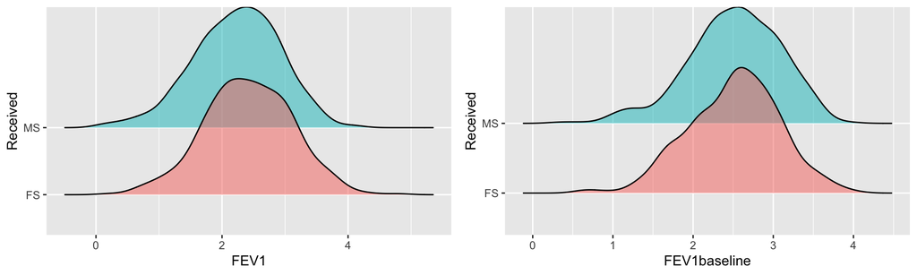

```r
multiplot(q3,p4,cols = 2)
```

### 3.2 Difference Analysis: Chi Square Test & Nonparametric Test

In order to prove that Ms surgery has obvious advantages over FS surgery, we need to carry out difference analysis, and carry out difference test on the same variable characteristics of patients undergoing different operations to find the results.  
From the previous references, we can find that in the comparative research papers of similar medical methods, chi square test is often used to analyze the difference of qualitative variables and t test is used to analyze the difference of quantitative variables. However, from the preliminary observation of the data, we can find that although the variables are divided into qualitative variables and quantitative variables, the quantitative variables do not meet the normal distribution. T-test belongs to parametric test, and its premise is that the test data must meet the normal distribution. Therefore, in this study, we will choose non parametric test to analyze the quantitative data.  
Nonparametric test is a method to infer the overall distribution form by using sample data when the overall variance is unknown or little known. Because the variables that need to compare differences cannot pass the normal test, we choose the Whitney rank sum test in the nonparametric test to test the two groups of independent samples. In addition, we choose to test the double paired samples.

#### 3.2.1 Preoperative Qualitative Variables

Methods: Chi square fit test can be used to compare the observed distribution with the expected distribution when there are two or more categories of discrete data. Chi square fit test is used to judge the fitting degree of proportional distribution of different types of results relative to an expected distribution.

(1) gender male: the p value of the test is 1, which is greater than the significance level, alpha = 0.05. We can conclude that there is no significant difference between the observed proportion and the expected proportion.

```r
before_Male <- data.frame(Male=c(length(which(data_e1_MS[,"Male"]=="TRUE")),length(which(data_e1_FS[,"Male"]=="TRUE"))),
                    Female=c(length(which(data_e1_MS[,"Male"]=="FALSE")),length(which(data_e1_FS[,"Male"]=="FALSE"))))
chisq.test(before_Male$Male,before_Male$Female)
```

```
##
##  Pearson's Chi-squared test with Yates'
##  continuity correction
##
## data:  before_Male$Male and before_Male$Female
## X-squared = 0, df = 1, p-value = 1
```

(2) COPD chronic obstructive pulmonary disease: the p value of the test is 1, which is greater than the significance level, alpha = 0.05. We can conclude that there is no significant difference between the observed proportion and the expected proportion.

```r
before_COPD <- data.frame(COPD=c(length(which(data_e1_MS[,"COPD"]=="TRUE")),length(which(data_e1_FS[,"COPD"]=="TRUE"))),
                    NO_COPD=c(length(which(data_e1_MS[,"COPD"]=="FALSE")),length(which(data_e1_FS[,"COPD"]=="FALSE"))))
chisq.test(before_COPD$COPD,before_COPD$NO_COPD)
```

```
##
##  Pearson's Chi-squared test with Yates'
##  continuity correction
##
## data:  before_COPD$COPD and before_COPD$NO_COPD
## X-squared = 0, df = 1, p-value = 1
```

(3) Comparison of walkingunassisted independent walking: the p value of the test is 1, which is greater than the significance level, alpha = 0.05. We can conclude that there is no significant difference between the observed proportion and the expected proportion.

```r
before_WalkingUnassisted <- data.frame(WalkingUnassisted=c(length(which(data_e1_MS[,"WalkingUnassisted"]=="TRUE")),length(which(data_e1_FS[,"WalkingUnassisted"]=="TRUE"))),
                    NO_WalkingUnassisted=c(length(which(data_e1_MS[,"WalkingUnassisted"]=="FALSE")),length(which(data_e1_FS[,"WalkingUnassisted"]=="FALSE"))))
chisq.test(before_WalkingUnassisted$WalkingUnassisted,before_WalkingUnassisted$NO_WalkingUnassisted)
```

```
##
##  Pearson's Chi-squared test with Yates'
##  continuity correction
##
## data:  before_WalkingUnassisted$WalkingUnassisted and before_WalkingUnassisted$NO_WalkingUnassisted
## X-squared = 0, df = 1, p-value = 1
```

(4) Whether carehome needs human care: the p value of the test is 1, which is greater than the significance level, alpha = 0.05. We can conclude that there is no significant difference between the observed proportion and the expected proportion.

```r
before_CareHome <- data.frame(CareHome=c(length(which(data_e1_MS[,"CareHome"]=="TRUE")),length(which(data_e1_FS[,"CareHome"]=="TRUE"))),
                    NO_CareHome=c(length(which(data_e1_MS[,"CareHome"]=="FALSE")),length(which(data_e1_FS[,"CareHome"]=="FALSE"))))
chisq.test(before_CareHome$CareHome,before_CareHome$NO_CareHome)
```

```
##
##  Pearson's Chi-squared test with Yates'
##  continuity correction
##
## data:  before_CareHome$CareHome and before_CareHome$NO_CareHome
## X-squared = 0, df = 1, p-value = 1
```

Conclusion:  
There is no significant difference in the proportion of qualitative variables between the two surgical methods.

#### 3.2.2 Preoperative Quantitative Variables

Method: Mann-whitney-u test, Mann Whitney rank sum test, was proposed by H.B. Mann and D.R. Whitney in 1947. It assumes that the two samples are from two populations that are exactly the same except the population mean, in order to test whether there is a significant difference between the mean of the two populations.

```r
wilcox.test(data_MS$age,data_FS$age)
```

```
##
##  Wilcoxon rank sum test with continuity
##  correction
##
## data:  data_MS$age and data_FS$age
## W = 104736, p-value = 0.9267
## alternative hypothesis: true location shift is not equal to 0
```

```r
wilcox.test(data_MS$BMI,data_FS$BMI)
```

```
##
##  Wilcoxon rank sum test with continuity
##  correction
##
## data:  data_MS$BMI and data_FS$BMI
## W = 106145, p-value = 0.7946
## alternative hypothesis: true location shift is not equal to 0
```

```r
wilcox.test(data_MS$CCS,data_FS$CCS)
```

```
##
##  Wilcoxon rank sum test with continuity
##  correction
##
## data:  data_MS$CCS and data_FS$CCS
## W = 105441, p-value = 0.9312
## alternative hypothesis: true location shift is not equal to 0
```

```r
wilcox.test(data_MS$FEV1baseline,data_FS$FEV1baseline)
```

```
##
##  Wilcoxon rank sum test with continuity
##  correction
##
## data:  data_MS$FEV1baseline and data_FS$FEV1baseline
## W = 106176, p-value = 0.7898
## alternative hypothesis: true location shift is not equal to 0
```

```r
wilcox.test(data_MS$NurseExperience,data_FS$NurseExperience)
```

```
##
##  Wilcoxon rank sum test with continuity
##  correction
##
## data:  data_MS$NurseExperience and data_FS$NurseExperience
## W = 101326, p-value = 0.3412
## alternative hypothesis: true location shift is not equal to 0
```

```r
wilcox.test(data_MS$EuroSCORE,data_FS$EuroSCORE)
```

```
##
##  Wilcoxon rank sum test with continuity
##  correction
##
## data:  data_MS$EuroSCORE and data_FS$EuroSCORE
## W = 106864, p-value = 0.6556
## alternative hypothesis: true location shift is not equal to 0
```

Result: The P values of all test results are greater than 0.05. We can consider that there is no significant difference between the two variables.

Conclusion:  
There is no significant difference in quantitative variables between the two surgical methods.

#### 3.2.3 Analysis of Postoperative Variables

```r
wilcox.test(data_MS$recovery_time,data_FS$recovery_time)
```

```
##
##  Wilcoxon rank sum test with continuity
##  correction
##
## data:  data_MS$recovery_time and data_FS$recovery_time
## W = 85202, p-value = 6.745e-07
## alternative hypothesis: true location shift is not equal to 0
```

```r
wilcox.test(data_MS$Cost,data_FS$Cost)
```

```
##
##  Wilcoxon rank sum test with continuity
##  correction
##
## data:  data_MS$Cost and data_FS$Cost
## W = 118072, p-value = 0.001238
## alternative hypothesis: true location shift is not equal to 0
```

```r
wilcox.test(data_MS$Pain,data_FS$Pain)
```

```
##
##  Wilcoxon rank sum test with continuity
##  correction
##
## data:  data_MS$Pain and data_FS$Pain
## W = 136250, p-value = 8.456e-15
## alternative hypothesis: true location shift is not equal to 0
```

```r
wilcox.test(data_MS$FEV1,data_FS$FEV1)
```

```
##
##  Wilcoxon rank sum test with continuity
##  correction
##
## data:  data_MS$FEV1 and data_FS$FEV1
## W = 90534, p-value = 0.0002841
## alternative hypothesis: true location shift is not equal to 0
```

```r
wilcox.test(data_MS$QALYs,data_FS$QALYs)
```

```
##
##  Wilcoxon rank sum test with continuity
##  correction
##
## data:  data_MS$QALYs and data_FS$QALYs
## W = 133445, p-value = 1.668e-12
## alternative hypothesis: true location shift is not equal to 0
```

Result: The P values of all test results are less than 0.05. We can consider that there is a significant difference between the two variables.

Conclusion:  
There were significant differences in the above postoperative variables between the two surgical methods.

#### 3.2.4 The Same Index - Comparison of Pulmonary Function

Methods:  
We selected Wilcoxon paired rank sum test, which is an improvement of sign sign test. Its hypothesis is reduced to whether the overall median is 0. The applicable condition is double paired sample test.

Results:  
The results showed that there were significant changes in vital capacity before and after the two operations.

```r
with(data_MS,wilcox.test(FEV1baseline,FEV1,paired = TRUE))
```

```
##
##  Wilcoxon signed rank test with continuity
##  correction
##
## data:  FEV1baseline and FEV1
## V = 77452, p-value < 2.2e-16
## alternative hypothesis: true location shift is not equal to 0
```

```r
#Changes of vital capacity after MS surgery
with(data_FS,wilcox.test(FEV1baseline,FEV1,paired = TRUE))
```

```
##
##  Wilcoxon signed rank test with continuity
##  correction
##
## data:  FEV1baseline and FEV1
## V = 76358, p-value = 2.354e-07
## alternative hypothesis: true location shift is not equal to 0
```

```r
#Changes of vital capacity after FS surgery
```

Conclusion: The difference analysis further verifies our conclusion in visualization, that is, there is no significant difference between MS operation and FS in preoperative patient indications, but there are differences between MS operation and FS in postoperative indexes. MS has the advantages of short postoperative recovery time and higher postoperative quality of life. However, it still has some disadvantages, such as high operation cost and high pain index. Therefore, it may cause difficulties for patients with poor families, but his advantages are still significant. It is believed that Ms surgery will be widely popularized and applied in clinic in the near future.

### 3.3 LM Regression Model

From the difference analysis, we can find that there is no significant difference in preoperative variables between the two operations. Therefore, we can think that there are no other influencing factors in the selection of the two operations. Then we conducted LM regression. We hope to establish a model to find out the main factors affecting the quality of life of postoperative patients.

#### 3.3.1 Viewing Quantitative Variable Correlation: Correlation Coefficient Matrix

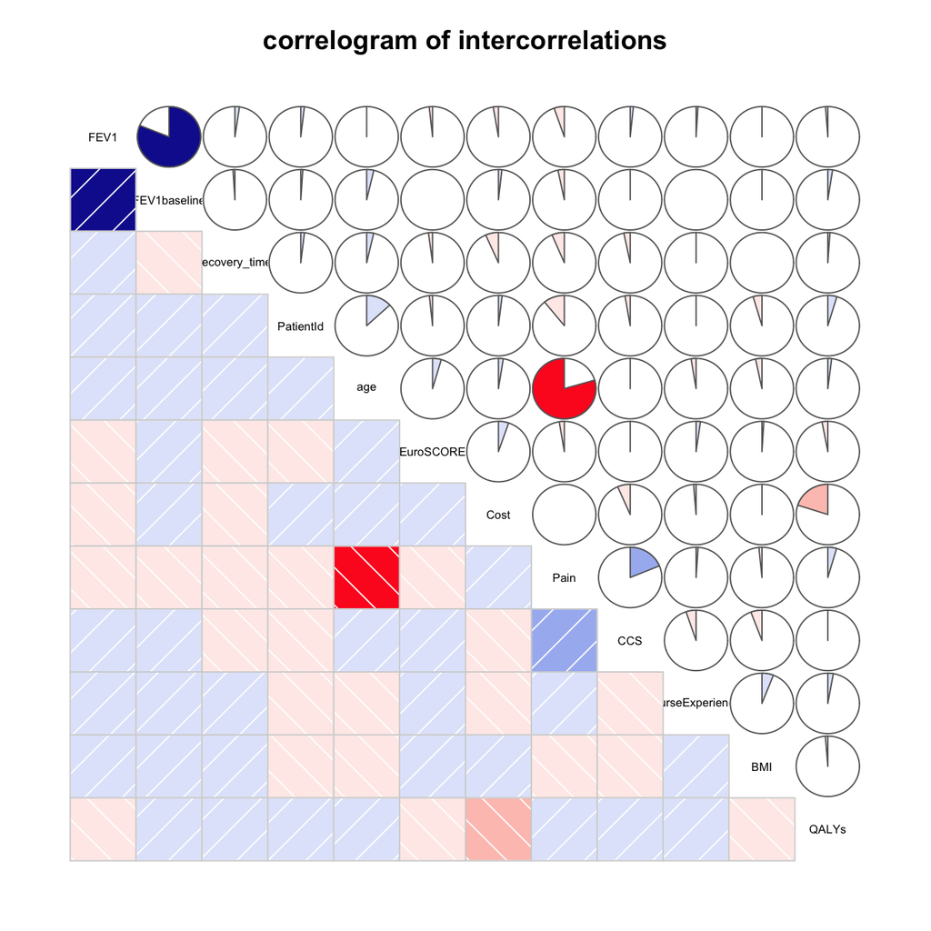

```r
corrgram(data1,order=TRUE,lower.panel=panel.shade,upper.panel=panel.pie,text.panel=panel.txt, main="correlogram of intercorrelations")
```

#### 3.3.2 Use LM to Find Out the Main Factors Affecting the Postoperative Quality of Life

##### 3.3.2.1 Preliminary Regression

We can find that the fitting degree of the model is not high. We suspect that this is due to the existence of multicollinearity between variables. Therefore, in order to solve the possible multicollinearity, we use the stepwise regression method to select the most appropriate model. When the AIC value reaches the minimum, the selected variables will be re used for LM regression.

```r
model1 <- lm(QALYs ~ Received+EuroSCORE+Male+CCS+BMI+COPD+WalkingUnassisted+CareHome+FEV1baseline+NurseExperience+Pain+Cost+age+recovery_time,data1)
summary(model1)
```

```
##
## Call:
## lm(formula = QALYs ~ Received + EuroSCORE + Male + CCS + BMI +
##     COPD + WalkingUnassisted + CareHome + FEV1baseline + NurseExperience +
##     Pain + Cost + age + recovery_time, data = data1)
##
## Residuals:
##      Min       1Q   Median       3Q      Max
## -0.66700 -0.13647  0.01186  0.15511  0.50170
##
## Coefficients:
##                         Estimate Std. Error
## (Intercept)            3.840e-01  2.694e-01
## ReceivedMS             1.220e-01  1.760e-02
## EuroSCORE             -3.314e-03  4.068e-03
## MaleTRUE              -4.566e-02  3.050e-02
## CCS                   -2.677e-03  7.438e-03
## BMI                   -8.109e-04  2.540e-03
## COPDTRUE              -1.998e-02  1.631e-02
## WalkingUnassistedTRUE  2.218e-02  3.739e-02
## CareHomeTRUE          -4.879e-03  1.853e-02
## FEV1baseline           2.338e-02  1.525e-02
## NurseExperience        1.158e-03  1.147e-03
## Pain                   6.309e-04  1.314e-03
## Cost                  -5.885e-06  8.152e-07
## age                    2.313e-03  2.959e-03
## recovery_time          1.136e-03  9.236e-04
##                       t value Pr(>|t|)
## (Intercept)             1.425    0.154
## ReceivedMS              6.929 8.03e-12 ***
## EuroSCORE              -0.815    0.415
## MaleTRUE               -1.497    0.135
## CCS                    -0.360    0.719
## BMI                    -0.319    0.750
## COPDTRUE               -1.225    0.221
## WalkingUnassistedTRUE   0.593    0.553
## CareHomeTRUE           -0.263    0.792
## FEV1baseline            1.533    0.126
## NurseExperience         1.010    0.313
## Pain                    0.480    0.631
## Cost                   -7.219 1.11e-12 ***
## age                     0.782    0.435
## recovery_time           1.230    0.219
## ---
## Signif. codes:
## 0 '***' 0.001 '**' 0.01 '*' 0.05 '.' 0.1 ' ' 1
##
## Residual standard error: 0.2295 on 904 degrees of freedom
## Multiple R-squared:  0.1116, Adjusted R-squared:  0.09779
## F-statistic: 8.108 on 14 and 904 DF,  p-value: < 2.2e-16
```

##### 3.3.2.2 Stepwise Regression - We Choose the Model with the Smallest AIC Value

```r
lm.step <- step(model1)
```

```
## Start:  AIC=-2690.33
## QALYs ~ Received + EuroSCORE + Male + CCS + BMI + COPD + WalkingUnassisted +
##     CareHome + FEV1baseline + NurseExperience + Pain + Cost +
##     age + recovery_time
##
##                     Df Sum of Sq    RSS     AIC
## - CareHome           1   0.00365 47.621 -2692.2
## - BMI                1   0.00537 47.623 -2692.2
## - CCS                1   0.00682 47.624 -2692.2
## - Pain               1   0.01215 47.629 -2692.1
## - WalkingUnassisted  1   0.01854 47.636 -2692.0
## - age                1   0.03218 47.649 -2691.7
## - EuroSCORE          1   0.03496 47.652 -2691.7
## - NurseExperience    1   0.05374 47.671 -2691.3
## - COPD               1   0.07908 47.696 -2690.8
## - recovery_time      1   0.07971 47.697 -2690.8
## <none>                           47.617 -2690.3
## - Male               1   0.11806 47.735 -2690.1
## - FEV1baseline       1   0.12382 47.741 -2689.9
## - Received           1   2.52924 50.146 -2644.8
## - Cost               1   2.74531 50.362 -2640.8
##
## Step:  AIC=-2692.25
## QALYs ~ Received + EuroSCORE + Male + CCS + BMI + COPD + WalkingUnassisted +
##     FEV1baseline + NurseExperience + Pain + Cost + age + recovery_time
##
##                     Df Sum of Sq    RSS     AIC
## - BMI                1   0.00564 47.626 -2694.2
## - CCS                1   0.00695 47.628 -2694.1
## - Pain               1   0.01186 47.633 -2694.0
## - WalkingUnassisted  1   0.01872 47.640 -2693.9
## - age                1   0.03193 47.653 -2693.6
## - EuroSCORE          1   0.03533 47.656 -2693.6
## - NurseExperience    1   0.05308 47.674 -2693.2
## - COPD               1   0.07951 47.700 -2692.7
## - recovery_time      1   0.08117 47.702 -2692.7
## <none>                           47.621 -2692.2
## - Male               1   0.11819 47.739 -2692.0
## - FEV1baseline       1   0.12394 47.745 -2691.9
## - Received           1   2.54254 50.163 -2646.4
```

[output cut: 118 more lines]

```
## <none>                       47.835 -2704.1
## - Male           1    0.1197 47.955 -2703.8
## - FEV1baseline   1    0.1220 47.957 -2703.8
## - Cost           1    2.8118 50.647 -2653.6
## - Received       1    3.4141 51.249 -2642.8
##
## Step:  AIC=-2704.58
## QALYs ~ Received + Male + FEV1baseline + Cost
##
##                Df Sum of Sq    RSS     AIC
## <none>                      47.916 -2704.6
## - FEV1baseline  1    0.1227 48.039 -2704.2
## - Male          1    0.1244 48.040 -2704.2
## - Cost          1    2.8624 50.778 -2653.2
## - Received      1    3.3339 51.250 -2644.8
```

Conclusion: The final model and variable obtained by stepwise regression is QALYs ~ received + male + fev1baseline + cost, which meets the minimum value of AIC = -2704.58.

##### 3.3.2.3 Thirdly, the modified model is fitted

```r
model2 <- lm(QALYs ~ Received + Male + FEV1baseline + Cost, data=data1)
summary(model2)
```

```
##
## Call:
## lm(formula = QALYs ~ Received + Male + FEV1baseline + Cost, data = data1)
##
## Residuals:
##     Min      1Q  Median      3Q     Max
## -0.6713 -0.1360  0.0096  0.1595  0.5087
##
## Coefficients:
##                Estimate Std. Error t value
## (Intercept)   5.318e-01  3.676e-02  14.465
## ReceivedMS    1.217e-01  1.526e-02   7.975
## MaleTRUE     -4.676e-02  3.036e-02  -1.540
## FEV1baseline  2.321e-02  1.517e-02   1.530
## Cost         -5.945e-06  8.046e-07  -7.389
##              Pr(>|t|)
## (Intercept)   < 2e-16 ***
## ReceivedMS   4.55e-15 ***
## MaleTRUE        0.124
## FEV1baseline    0.126
## Cost         3.33e-13 ***
## ---
## Signif. codes:
## 0 '***' 0.001 '**' 0.01 '*' 0.05 '.' 0.1 ' ' 1
##
## Residual standard error: 0.229 on 914 degrees of freedom
## Multiple R-squared:  0.106,  Adjusted R-squared:  0.1021
## F-statistic: 27.09 on 4 and 914 DF,  p-value: < 2.2e-16
```

#### 3.3.3 Model Test

##### 3.3.3.1 Significance Test

According to the goodness of fit R ^ 2 = 0.1021, we can find that the fitting degree of the model is still not high, but the p value < 0.05, the model is still significant.

##### 3.3.3.2 Heteroscedasticity Test

According to the diagram, we can think that the model has no obvious heteroscedasticity problem.

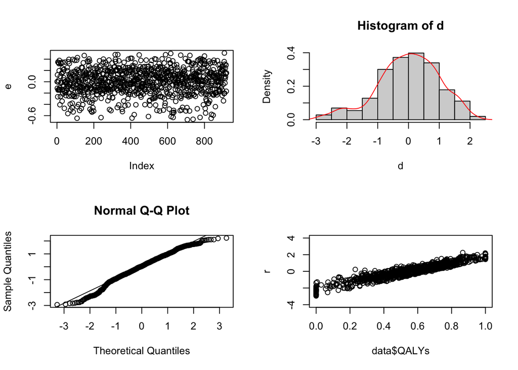

```r
par(mfrow=c(2,2))
e <- resid(model2)
plot(e)
d <- e/sqrt(deviance(model2)/919) #Standardized residual
hist(d,probability = T)
#Draw regression standardized residual probability diagram
lines(density(d),col='red')  #Add regression line
qqnorm(d) #Normality test of QQ-plot
qqline(d) #Add trend lin
r <- rstudent(model2)
plot(data$QALYs,r,ylim = c(-4,4),xlim = c(0,1))
```

```r
#Normalized residuals versus response variable graphs
```

Conclusion:  
From this, we can think that the model is feasible. Our conclusion is also preliminarily established.

## 4 Conclusions

### 4.1 Research Findings

Through the difference analysis of the same variables of different operations, we can find that there is no significant difference between the two operations in preoperative patient indications. We can think that the experimental data are random in operation selection; In addition, we can see that the recovery time and quality of life of MS surgery are significantly different from those of traditional FS surgery.  
In addition, we established LM regression model through stepwise regression method, and finally found out that the two main factors affecting the postoperative quality of life of patients are the mode of operation, MS or FS, and the cost of treatment.

### 4.3 Suggestions and Countermeasures

Through comprehensive analysis, we can think that Ms surgery has obvious advantages over FS surgery and can significantly improve the postoperative quality of life of patients. However, as a new surgical method, Ms still has the disadvantage of high cost, and high cost will often become a difficulty for many patients. Therefore, we can hope that this operation can be rapidly developed and popularized in the new era, so as to gradually reduce the operation cost and benefit more patients.  
In addition, from the analysis of patient characteristics, we also found the main population requiring AVR surgery, men around the age of 60, especially patients with chronic obstructive pulmonary disease and other related diseases. Therefore, we can advocate and promote regular physical examination, encourage these groups to strengthen exercise, and curb the emergence of the disease from the source of the disease, so as to further improve people’s quality of life.

## 5.Reference

[1]王征. 右胸小切口与胸骨正中切口二尖瓣置换术的临床对照研究[D]. 浙江大学, 2011.

[2]陈海生, 程云阁, 钟焕清,等. 胸腔镜与开胸手术治疗先天性心脏病的疗效比较[J]. 中国微创外科杂志, 2005, 5(008):634-635.

[3] Lydia R , Michael R , Steven H . Is a port-access mitral valve repair superior to the sternotomy approach in accelerating postoperative recovery?[J]. Interactive Cardiovascular & Thoracic Surgery(4):678.

[4] Paul M , Ansar H , Randolph C W . Minimally invasive mitral valve surgery: a systematic review and meta-analysis.[J]. Eur J Cardiothorac Surg, 2008(5):943-952.

[5] Cosgrove D M , Sabik J F . Minimally invasive approach for aortic valve operations.[J]. Annals of Thoracic Surgery, 1996, 62(2):596-597.